# electric_cars

```python
import pandas as pd
import numpy as np
import matplotlib.pyplot as plt
import matplotlib.dates as mdates
import seaborn as sns
import plotly.express as px
import geopandas as gpd
```

```python
file_path = "C:/Users/ignac/Downloads/Electric_Vehicle_Population_Data.csv"
df = pd.read_csv(file_path)
```

```python
# Check for missing values
print(df.isnull().sum())
```

```
VIN (1-10)                                             0
County                                                 3
City                                                   3
State                                                  0
Postal Code                                            3
Model Year                                             0
Make                                                   0
Model                                                  0
Electric Vehicle Type                                  0
Clean Alternative Fuel Vehicle (CAFV) Eligibility      0
Electric Range                                        18
Base MSRP                                             18
Legislative District                                 474
DOL Vehicle ID                                         0
Vehicle Location                                      10
Electric Utility                                       3
2020 Census Tract                                      3
dtype: int64
```

```python
df.duplicated().sum()
```

```
np.int64(0)
```

```python
df.info()
```

```
<class 'pandas.core.frame.DataFrame'>
RangeIndex: 223995 entries, 0 to 223994
Data columns (total 17 columns):
 #   Column                                             Non-Null Count   Dtype
---  ------                                             --------------   -----
 0   VIN (1-10)                                         223995 non-null  object
 1   County                                             223992 non-null  object
 2   City                                               223992 non-null  object
 3   State                                              223995 non-null  object
 4   Postal Code                                        223992 non-null  float64
 5   Model Year                                         223995 non-null  int64
 6   Make                                               223995 non-null  object
 7   Model                                              223995 non-null  object
 8   Electric Vehicle Type                              223995 non-null  object
 9   Clean Alternative Fuel Vehicle (CAFV) Eligibility  223995 non-null  object
 10  Electric Range                                     223977 non-null  float64
 11  Base MSRP                                          223977 non-null  float64
 12  Legislative District                               223521 non-null  float64
 13  DOL Vehicle ID                                     223995 non-null  int64
 14  Vehicle Location                                   223985 non-null  object
 15  Electric Utility                                   223992 non-null  object
 16  2020 Census Tract                                  223992 non-null  float64
dtypes: float64(5), int64(2), object(10)
memory usage: 29.1+ MB
```

```python
df.describe()
```

|  | Postal Code | Model Year | Electric Range | Base MSRP | Legislative District | DOL Vehicle ID | 2020 Census Tract |
| --- | --- | --- | --- | --- | --- | --- | --- |
| count | 223992.000000 | 223995.000000 | 223977.000000 | 223977.000000 | 223521.000000 | 2.239950e+05 | 2.239920e+05 |
| mean | 98176.491165 | 2021.264408 | 47.736187 | 829.894386 | 28.876361 | 2.329328e+08 | 5.297997e+10 |
| std | 2544.240509 | 2.989676 | 84.987140 | 7372.509049 | 14.911023 | 6.884329e+07 | 1.531491e+09 |
| min | 1731.000000 | 1999.000000 | 0.000000 | 0.000000 | 1.000000 | 4.385000e+03 | 1.001020e+09 |
| 25% | 98052.000000 | 2020.000000 | 0.000000 | 0.000000 | 17.000000 | 2.008002e+08 | 5.303301e+10 |
| 50% | 98126.000000 | 2022.000000 | 0.000000 | 0.000000 | 32.000000 | 2.482992e+08 | 5.303303e+10 |
| 75% | 98374.000000 | 2023.000000 | 39.000000 | 0.000000 | 42.000000 | 2.673973e+08 | 5.305307e+10 |
| max | 99577.000000 | 2025.000000 | 337.000000 | 845000.000000 | 49.000000 | 4.792548e+08 | 5.602100e+10 |

```python
df.columns
```

```
Index(['VIN (1-10)', 'County', 'City', 'State', 'Postal Code', 'Model Year',
       'Make', 'Model', 'Electric Vehicle Type',
       'Clean Alternative Fuel Vehicle (CAFV) Eligibility', 'Electric Range',
       'Base MSRP', 'Legislative District', 'DOL Vehicle ID',
       'Vehicle Location', 'Electric Utility', '2020 Census Tract'],
      dtype='object')
```

```python
df.shape
```

```
(223995, 17)
```

```python
df.head()
```

|  | VIN (1-10) | County | City | State | Postal Code | Model Year | Make | Model | Electric Vehicle Type | Clean Alternative Fuel Vehicle (CAFV) Eligibility | Electric Range | Base MSRP | Legislative District | DOL Vehicle ID | Vehicle Location | Electric Utility | 2020 Census Tract |
| --- | --- | --- | --- | --- | --- | --- | --- | --- | --- | --- | --- | --- | --- | --- | --- | --- | --- |
| 0 | 1C4JJXP66P | Kitsap | Poulsbo | WA | 98370.0 | 2023 | JEEP | WRANGLER | Plug-in Hybrid Electric Vehicle (PHEV) | Not eligible due to low battery range | 21.0 | 0.0 | 23.0 | 258127145 | POINT (-122.64681 47.73689) | PUGET SOUND ENERGY INC | 5.303509e+10 |
| 1 | 1G1FX6S08K | Snohomish | Lake Stevens | WA | 98258.0 | 2019 | CHEVROLET | BOLT EV | Battery Electric Vehicle (BEV) | Clean Alternative Fuel Vehicle Eligible | 238.0 | 0.0 | 44.0 | 4735426 | POINT (-122.06402 48.01497) | PUGET SOUND ENERGY INC | 5.306105e+10 |
| 2 | WBY1Z2C58F | King | Seattle | WA | 98116.0 | 2015 | BMW | I3 | Battery Electric Vehicle (BEV) | Clean Alternative Fuel Vehicle Eligible | 81.0 | 0.0 | 34.0 | 272697666 | POINT (-122.41067 47.57894) | CITY OF SEATTLE - (WA)\|CITY OF TACOMA - (WA) | 5.303301e+10 |
| 3 | 5YJ3E1EBXK | King | Seattle | WA | 98178.0 | 2019 | TESLA | MODEL 3 | Battery Electric Vehicle (BEV) | Clean Alternative Fuel Vehicle Eligible | 220.0 | 0.0 | 37.0 | 477309682 | POINT (-122.23825 47.49461) | CITY OF SEATTLE - (WA)\|CITY OF TACOMA - (WA) | 5.303301e+10 |
| 4 | 5YJSA1V24F | Yakima | Selah | WA | 98942.0 | 2015 | TESLA | MODEL S | Battery Electric Vehicle (BEV) | Clean Alternative Fuel Vehicle Eligible | 208.0 | 0.0 | 15.0 | 258112970 | POINT (-120.53145 46.65405) | PACIFICORP | 5.307700e+10 |

```python
df.tail()
```

|  | VIN (1-10) | County | City | State | Postal Code | Model Year | Make | Model | Electric Vehicle Type | Clean Alternative Fuel Vehicle (CAFV) Eligibility | Electric Range | Base MSRP | Legislative District | DOL Vehicle ID | Vehicle Location | Electric Utility | 2020 Census Tract |
| --- | --- | --- | --- | --- | --- | --- | --- | --- | --- | --- | --- | --- | --- | --- | --- | --- | --- |
| 223990 | 7SAYGDEE4R | Pierce | Puyallup | WA | 98374.0 | 2024 | TESLA | MODEL Y | Battery Electric Vehicle (BEV) | Eligibility unknown as battery range has not b... | 0.0 | 0.0 | 2.0 | 264662359 | POINT (-122.27575 47.13959) | PUGET SOUND ENERGY INC\|\|CITY OF TACOMA - (WA) | 5.305307e+10 |
| 223991 | WBY8P2C00M | Snohomish | Lake Stevens | WA | 98258.0 | 2021 | BMW | I3 | Battery Electric Vehicle (BEV) | Eligibility unknown as battery range has not b... | 0.0 | 0.0 | 44.0 | 157728168 | POINT (-122.06402 48.01497) | PUGET SOUND ENERGY INC | 5.306105e+10 |
| 223992 | JN1AZ0CP3B | Pierce | University Place | WA | 98466.0 | 2011 | NISSAN | LEAF | Battery Electric Vehicle (BEV) | Clean Alternative Fuel Vehicle Eligible | 73.0 | 0.0 | 28.0 | 261733433 | POINT (-122.53756 47.23165) | BONNEVILLE POWER ADMINISTRATION\|\|CITY OF TACOM... | 5.305307e+10 |
| 223993 | 5YJ3E1EA2R | Pierce | Puyallup | WA | 98374.0 | 2024 | TESLA | MODEL 3 | Battery Electric Vehicle (BEV) | Eligibility unknown as battery range has not b... | 0.0 | 0.0 | 25.0 | 275283487 | POINT (-122.27575 47.13959) | PUGET SOUND ENERGY INC\|\|CITY OF TACOMA - (WA) | 5.305307e+10 |
| 223994 | WBY8P8C57K | King | Woodinville | WA | 98072.0 | 2019 | BMW | I3 | Plug-in Hybrid Electric Vehicle (PHEV) | Clean Alternative Fuel Vehicle Eligible | 126.0 | 0.0 | 45.0 | 267288801 | POINT (-122.15545 47.75448) | PUGET SOUND ENERGY INC\|\|CITY OF TACOMA - (WA) | 5.303303e+10 |

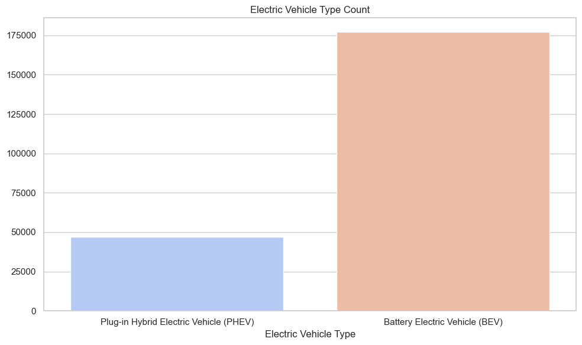

```python
# Create a figure and axes
fig, axes = plt.subplots(1, 1, figsize=(10, 6))

# Count of Electric Vehicle Type
sns.countplot(data=df, x='Electric Vehicle Type', hue='Electric Vehicle Type', palette='coolwarm', ax=axes, dodge=False)
axes.set_title("Electric Vehicle Type Count")
axes.set_xlabel("Electric Vehicle Type")
axes.set_ylabel("")

# Check if the legend exists before removing it
if axes.get_legend() is not None:
	axes.get_legend().remove()

# Show the plot
plt.tight_layout()
plt.show()
```

Visualization Interpretation

X-axis Represents the types of electric vehicles, specifically "Plug-in Hybrid Electric Vehicle (PHEV)" and "Battery Electric Vehicle (BEV)".

Y-axis Represents the count of each type of vehicle.

Observations

The count of "Battery Electric Vehicle (BEV)" is significantly higher than that of "Plug-in Hybrid Electric Vehicle (PHEV)".

The y-axis values suggest that there are around 175,000 BEVs and fewer PHEVs, though the exact number for PHEVs isn't specified in the provided content.

```
Index(['featurecla', 'scalerank', 'LABELRANK', 'SOVEREIGNT', 'SOV_A3',
       'ADM0_DIF', 'LEVEL', 'TYPE', 'TLC', 'ADMIN',
       ...
       'FCLASS_TR', 'FCLASS_ID', 'FCLASS_PL', 'FCLASS_GR', 'FCLASS_IT',
       'FCLASS_NL', 'FCLASS_SE', 'FCLASS_BD', 'FCLASS_UA', 'geometry'],
      dtype='object', length=169)
```

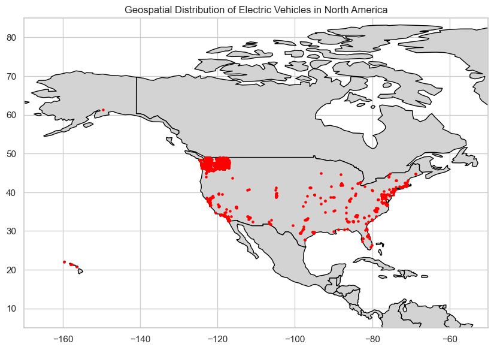

```python
from shapely.geometry import Point

# Path to extracted file
shapefile_path = r"C:\Users\ignac\Downloads\ne_110m_admin_0_countries\ne_110m_admin_0_countries.shp"

# Load the world map from the downloaded file
world = gpd.read_file(shapefile_path)

# Inspect the columns of the world GeoDataFrame
print(world.columns)

# Filter for North America using the correct column name
north_america = world[world['REGION_UN'] == 'Americas']

# Filter out rows with invalid 'Vehicle Location' values
df_valid_location = df[df['Vehicle Location'].apply(lambda x: isinstance(x, str))]

# Create a GeoDataFrame with vehicle locations
geometry = [Point(float(x.split(' ')[1][1:-1]), float(x.split(' ')[2][:-1])) for x in df_valid_location['Vehicle Location']]
gdf = gpd.GeoDataFrame(df_valid_location, geometry=geometry)

# Plot the North American region
fig, ax = plt.subplots(figsize=(10, 7))
north_america.plot(ax=ax, color='lightgray', edgecolor='black')

# Plot vehicle locations
gdf.plot(ax=ax, marker='o', color='red', markersize=5)

# Set zoom-in limits (approximate bounding box for North America)
ax.set_xlim(-170, -50)  # Longitude range
ax.set_ylim(5, 85)      # Latitude range

plt.title('Geospatial Distribution of Electric Vehicles in North America')
plt.show()
```

```python
# Interactive scatter plot
fig = px.scatter(df, x='Model Year', y='Electric Range', color='Make', hover_data=['Model'])
fig.update_layout(title='Electric Range vs Model Year by Make', xaxis_title='Model Year', yaxis_title='Electric Range')
fig.show()

# Filter out rows where 'Vehicle Location' is not a string
df_valid_location = df[df['Vehicle Location'].apply(lambda x: isinstance(x, str))]
```

[output not shown]

Visualization Interpretation

X-axis Represents the "Model Year" of the electric vehicles.

Y-axis Represents the "Electric Range" of the vehicles.

Observations

The electric range varies, and the plot likely shows trends in how the range has improved over the years for different makes.

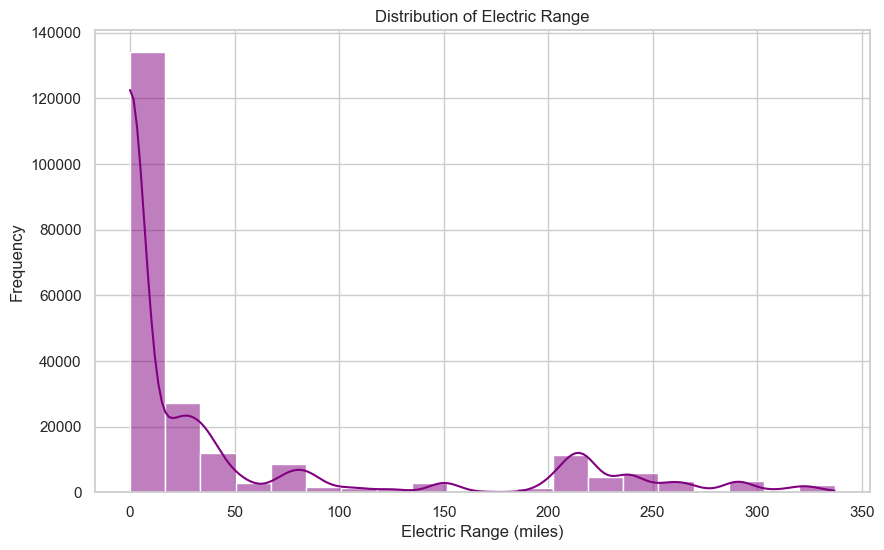

```python
# Distribution of Electric Range
plt.figure(figsize=(10, 6))
sns.histplot(df['Electric Range'], bins=20, kde=True, color='purple')
plt.title('Distribution of Electric Range')
plt.xlabel('Electric Range (miles)')
plt.ylabel('Frequency')
plt.show()
```

Visualization Interpretation

X-axis Represents the 'Electric Range' in miles.

Y-axis Represents the frequency of vehicles within each range bin.

Observations

The histogram shows the distribution of electric ranges, with bins representing different ranges of miles.

The KDE overlay provides a smooth estimate of the distribution, highlighting the density of data points.

The distribution appears to be right-skewed, with a higher frequency of vehicles having lower electric ranges and a tail extending towards higher ranges.

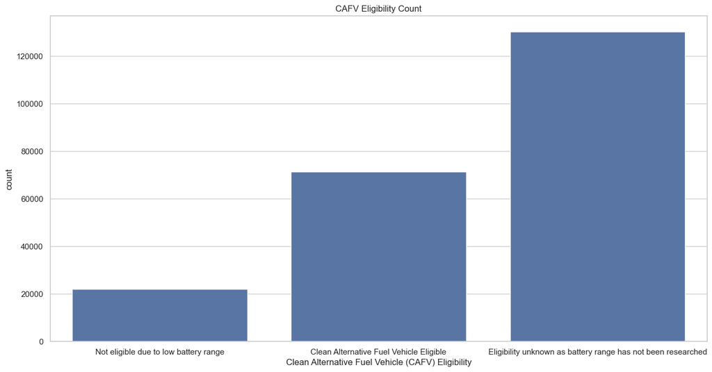

```python
# CAFV Eligibility Count
fig, ax = plt.subplots(figsize=(16, 8))
sns.countplot(data=df, x='Clean Alternative Fuel Vehicle (CAFV) Eligibility', ax=ax)
ax.set_title("CAFV Eligibility Count")
plt.show()
```

Visualization Interpretation

X-axis: Represents the different CAFV eligibility statuses.

Y-axis: Represents the count of vehicles in each eligibility category.

Observations

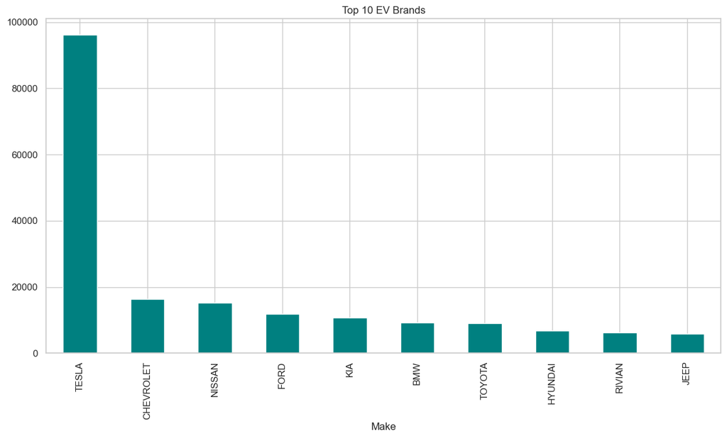

```python
# Top 10 EV Brands
fig, ax = plt.subplots(figsize=(14, 7))
df['Make'].value_counts().nlargest(10).plot(kind='bar', ax=ax, color='teal')
ax.set_title("Top 10 EV Brands")
plt.show()
```

Visualization Interpretation:

X-axis Represents the EV brands.

Y-axis Represents the count of vehicles for each brand.

Observations

The bar chart highlights the top 10 EV brands, with Tesla having the highest count, followed by Chevrolet, Nissan, Ford, Kia, BMW, Toyota, Hyundai, Rivian, and Jeep.

Tesla significantly outperforms other brands in terms of the number of vehicles in the dataset.

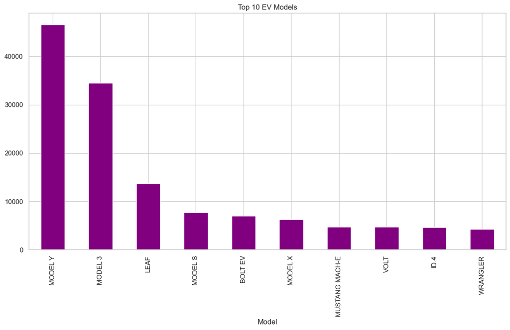

```python
# Top 10 EV Models
fig, ax = plt.subplots(figsize=(14, 7))
df['Model'].value_counts().nlargest(10).plot(kind='bar', ax=ax, color='purple')
ax.set_title("Top 10 EV Models")
plt.show()
```

Visualization Interpretation

X-axis Represents the EV models.

Y-axis Represents the count of vehicles for each model.

Observations

The bar chart highlights the top 10 EV models, with models like "MODEL Y", "MODEL 3", "LEAF", "MODEL S", "BOLT EV", and "MODEL X" being prominent.

The visualization aims to show which EV models are most common or popular in the dataset.

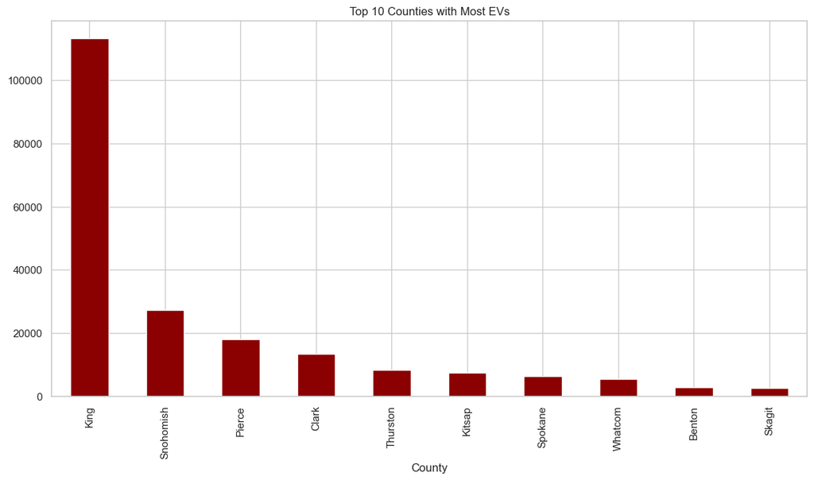

```python
# EV Distribution by County
fig, ax = plt.subplots(figsize=(14, 7))
df['County'].value_counts().nlargest(10).plot(kind='bar', ax=ax, color='darkred')
ax.set_title("Top 10 Counties with Most EVs")
plt.show()
```

Visualization Interpretation

X-axis Represents the counties.

Y-axis Represents the count of EVs in each county.

Observations

The bar chart highlights the top 10 counties with the most EVs, with King County having the highest count, followed by Snohomish, Pierce, Clark, Thurston, Kitsap, Spokane, Whatcom, Benton, and Skagit.

King County significantly outperforms other counties in terms of the number of EVs.

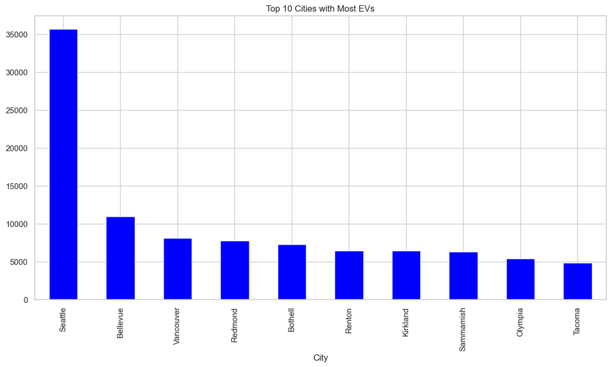

```python
# EV Distribution by City
fig, ax = plt.subplots(figsize=(14, 7))
df['City'].value_counts().nlargest(10).plot(kind='bar', ax=ax, color='blue')
ax.set_title("Top 10 Cities with Most EVs")
plt.show()
```

Visualization Interpretation:

X-axis Represents the cities.

Y-axis Represents the count of EVs in each city.

Observations

Seattle significantly outperforms other cities in terms of the number of EVs.

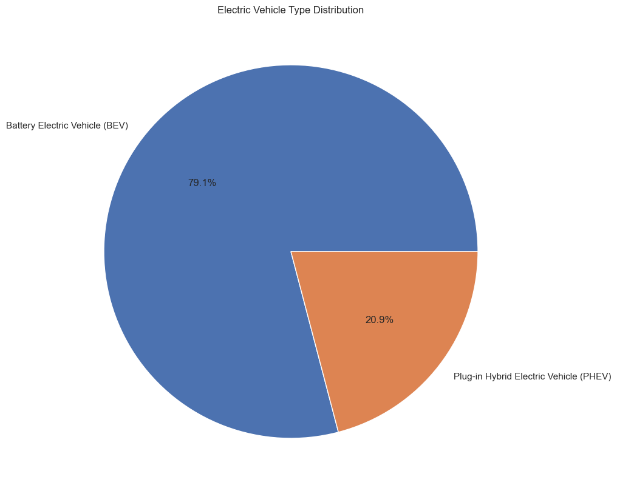

```python
# Electric Vehicle Type Distribution (Pie Chart)
fig, ax = plt.subplots(figsize=(10, 10))
df['Electric Vehicle Type'].value_counts().plot(kind='pie', autopct='%1.1f%%', ax=ax)
ax.set_title("Electric Vehicle Type Distribution")
ylabel = ax.set_ylabel('')
plt.show()
```

Visualization Interpretation

Categories The main categories are "Battery Electric Vehicle (BEV)" and "Plug-in Hybrid Electric Vehicle (PHEV)".

Observations

The pie chart clearly shows that Battery Electric Vehicles (BEVs) are more prevalent than Plug-in Hybrid Electric Vehicles (PHEVs) in the dataset.

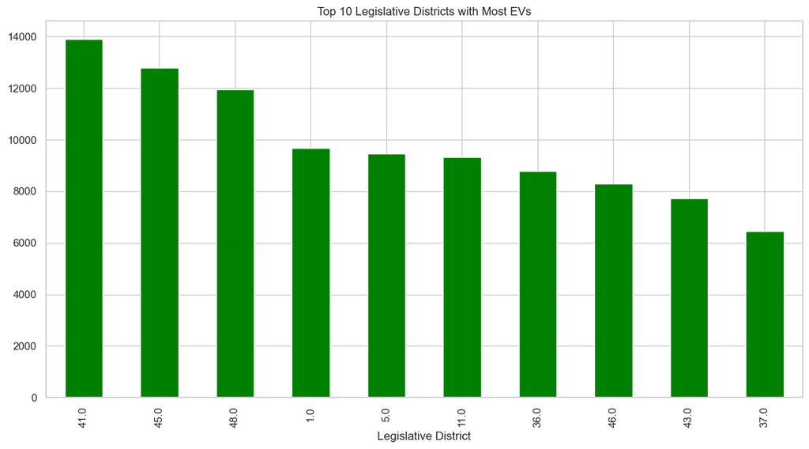

```python
# Legislative Districts with Most EVs
fig, ax = plt.subplots(figsize=(14, 7))
df['Legislative District'].value_counts().nlargest(10).plot(kind='bar', ax=ax, color='green')
ax.set_title("Top 10 Legislative Districts with Most EVs")
plt.show()
```

Visualization Interpretation

X-axis Represents the legislative districts.

Y-axis Represents the count of EVs in each district.

Observations

The bar chart highlights the top 10 legislative districts with the most EVs, with districts like 41.0, 45.0, and 48.0 having the highest counts.

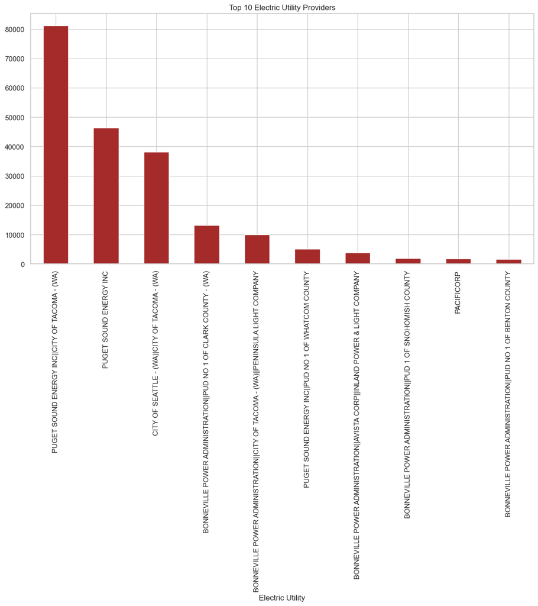

```python
# Top Electric Utility Providers
fig, ax = plt.subplots(figsize=(14, 7))
df['Electric Utility'].value_counts().nlargest(10).plot(kind='bar', ax=ax, color='brown')
ax.set_title("Top 10 Electric Utility Providers")
plt.show()
```

Visualization Interpretation

X-axis Represents the electric utility providers.

Y-axis Represents the count of EVs serviced by each provider.

Observations

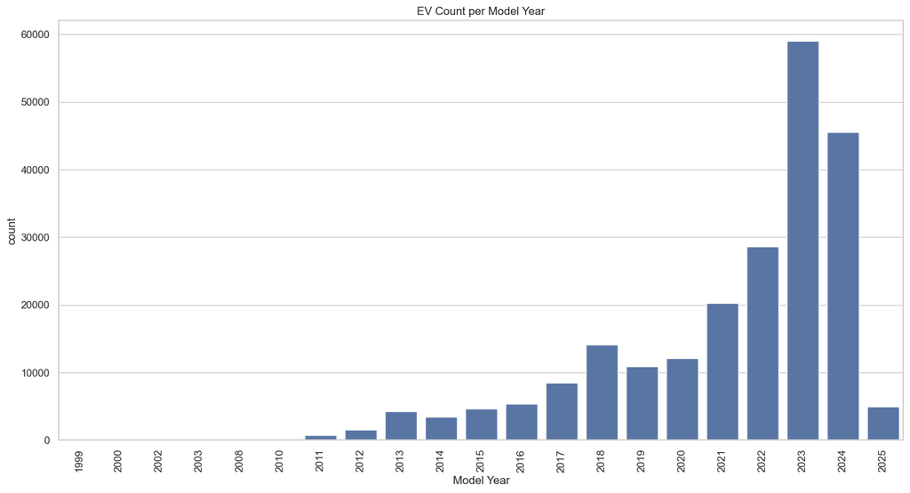

```python
# EV Count per Model Year
fig, ax = plt.subplots(figsize=(16, 8))
sns.countplot(data=df, x='Model Year', ax=ax)
ax.set_title("EV Count per Model Year")
ax.tick_params(axis='x', rotation=90)
plt.show()
```

Visualization Interpretation

Y-axis Represents the count of EVs for each model year.

Observations

There is a noticeable increase in the count of EVs over the years, particularly from around 2010 onwards.

The most recent model years (2020-2024) show a significant rise in EV counts, indicating a growing trend in EV adoption.

The earlier years (1999-2005) have much lower counts, reflecting the initial stages of EV development and adoption.